# Sixth Week: Linear Models

House price prediction

Mina Moosavi - 93106788

2018-04-13 02:44:25

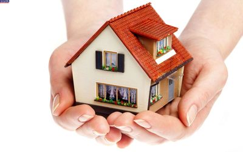

> با توجه به داده های قیمت منازل لطفا با سوالات زیر پاسخ دهید.

داده ها و کتابخانه ها:

```r
library(readr)
library(dplyr)
library(ggplot2)
library(highcharter)

dic_var = read_delim("data/dictionnaire_variables.csv",delim = ";")
dic_nvx = read_csv("data/dictionnaire_niveaux.csv",
                   col_names = c("variable", "label", "Type")) %>% select(1:3)
house = read_csv("data/train.csv")
house_test = read_csv(("data/test.csv"))
```

۱. ماتریس همبستگی متغیرهای مختلف را به دست آورده و سپس رسم نمایید. اعداد به دست آمده را با آزمون فرض معناداری همبستگی بسنجید و سپس ده متغیری که همبستگی بالاتری با قیمت دارند را مشخص نمایید.

برای این سوال تنها متغیرهای عددی در نظر گرفته شده اند، زیرا در صورتی که مقادیر غیر عددی را به عددی تبدیل کنیم، معنی آن ها عوض می شود و در رگرسیون نتیجه ی خوبی نمی دهد. هم چنین برای آزمون فرض همبستگی داده ها از corr.test استفاده شده است و خطا ۰.۰۵ در نظر گرفته شده است. هم چنین فرض صفر عدم وجود رابطه ی غیرخطی بین متغیرها است. در نتیجه در جواب هر چه احتمالات کمتر بوده باشد، فرض صفر رد می شود و متغیرها دارای رابطه ی خطی هستند.

```r
library(corrplot)
library(psych)

house_numeric <- house %>% select_if(is.numeric)
all_cors = cor(house_numeric)
knitr::kable(all_cors)
```

|  | Id | MSSubClass | LotFrontage | LotArea | OverallQual | OverallCond | YearBuilt | YearRemodAdd | MasVnrArea | BsmtFinSF1 | BsmtFinSF2 | BsmtUnfSF | TotalBsmtSF | 1stFlrSF | 2ndFlrSF | LowQualFinSF | GrLivArea | BsmtFullBath | BsmtHalfBath | FullBath | HalfBath | BedroomAbvGr | KitchenAbvGr | TotRmsAbvGrd | Fireplaces | GarageYrBlt | GarageCars | GarageArea | WoodDeckSF | … |
| --- | --- | --- | --- | --- | --- | --- | --- | --- | --- | --- | --- | --- | --- | --- | --- | --- | --- | --- | --- | --- | --- | --- | --- | --- | --- | --- | --- | --- | --- | --- |
| Id | 1.0000000 | 0.0111565 | NA | -0.0332255 | -0.0283648 | 0.0126089 | -0.0127127 | -0.0219976 | NA | -0.0050240 | -0.0059677 | -0.0079397 | -0.0154146 | 0.0104960 | 0.0055898 | -0.0442300 | 0.0082728 | 0.0022886 | -0.0201547 | 0.0055875 | 0.0067838 | 0.0377186 | 0.0029512 | 0.0272387 | -0.0197716 | NA | 0.0165697 | 0.0176338 | -0.0296432 | … |
| MSSubClass | 0.0111565 | 1.0000000 | NA | -0.1397811 | 0.0326277 | -0.0593158 | 0.0278501 | 0.0405810 | NA | -0.0698357 | -0.0656486 | -0.1407595 | -0.2385184 | -0.2517584 | 0.3078857 | 0.0464738 | 0.0748532 | 0.0034910 | -0.0023325 | 0.1316082 | 0.1773544 | -0.0234380 | 0.2817210 | 0.0403801 | -0.0455693 | NA | -0.0401098 | -0.0986715 | -0.0125794 | … |
| LotFrontage | NA | NA | 1 | NA | NA | NA | NA | NA | NA | NA | NA | NA | NA | NA | NA | NA | NA | NA | NA | NA | NA | NA | NA | NA | NA | NA | NA | NA | NA | … |
| LotArea | -0.0332255 | -0.1397811 | NA | 1.0000000 | 0.1058057 | -0.0056363 | 0.0142277 | 0.0137884 | NA | 0.2141031 | 0.1111697 | -0.0026184 | 0.2608331 | 0.2994746 | 0.0509859 | 0.0047790 | 0.2631162 | 0.1581545 | 0.0480456 | 0.1260306 | 0.0142595 | 0.1196899 | -0.0177839 | 0.1900148 | 0.2713640 | NA | 0.1548707 | 0.1804028 | 0.1716977 | … |
| OverallQual | -0.0283648 | 0.0326277 | NA | 0.1058057 | 1.0000000 | -0.0919323 | 0.5723228 | 0.5506839 | NA | 0.2396660 | -0.0591187 | 0.3081589 | 0.5378085 | 0.4762238 | 0.2954929 | -0.0304293 | 0.5930074 | 0.1110978 | -0.0401502 | 0.5505997 | 0.2734581 | 0.1016764 | -0.1838822 | 0.4274523 | 0.3967650 | NA | 0.6006707 | 0.5620218 | 0.2389234 | … |
| OverallCond | 0.0126089 | -0.0593158 | NA | -0.0056363 | -0.0919323 | 1.0000000 | -0.3759832 | 0.0737415 | NA | -0.0462309 | 0.0402292 | -0.1368406 | -0.1710975 | -0.1442028 | 0.0289421 | 0.0254943 | -0.0796859 | -0.0549415 | 0.1178209 | -0.1941495 | -0.0607693 | 0.0129801 | -0.0870009 | -0.0575832 | -0.0238200 | NA | -0.1857575 | -0.1515214 | -0.0033337 | … |
| YearBuilt | -0.0127127 | 0.0278501 | NA | 0.0142277 | 0.5723228 | -0.3759832 | 1.0000000 | 0.5928550 | NA | 0.2495032 | -0.0491068 | 0.1490404 | 0.3914520 | 0.2819859 | 0.0103077 | -0.1837843 | 0.1990097 | 0.1875985 | -0.0381618 | 0.4682708 | 0.2426559 | -0.0706512 | -0.1748002 | 0.0955891 | 0.1477164 | NA | 0.5378501 | 0.4789538 | 0.2248801 | … |
| YearRemodAdd | -0.0219976 | 0.0405810 | NA | 0.0137884 | 0.5506839 | 0.0737415 | 0.5928550 | 1.0000000 | NA | 0.1284505 | -0.0677585 | 0.1811331 | 0.2910656 | 0.2403793 | 0.1400238 | -0.0624191 | 0.2873885 | 0.1194699 | -0.0123370 | 0.4390465 | 0.1833306 | -0.0405809 | -0.1495975 | 0.1917398 | 0.1125813 | NA | 0.4206222 | 0.3715998 | 0.2057259 | … |
| MasVnrArea | NA | NA | NA | NA | NA | NA | NA | NA | 1 | NA | NA | NA | NA | NA | NA | NA | NA | NA | NA | NA | NA | NA | NA | NA | NA | NA | NA | NA | NA | … |
| BsmtFinSF1 | -0.0050240 | -0.0698357 | NA | 0.2141031 | 0.2396660 | -0.0462309 | 0.2495032 | 0.1284505 | NA | 1.0000000 | -0.0501174 | -0.4952515 | 0.5223961 | 0.4458627 | -0.1370790 | -0.0645026 | 0.2081711 | 0.6492118 | 0.0674185 | 0.0585431 | 0.0042624 | -0.1073547 | -0.0810069 | 0.0443156 | 0.2600109 | NA | 0.2240535 | 0.2969704 | 0.2043061 | … |
| BsmtFinSF2 | -0.0059677 | -0.0656486 | NA | 0.1111697 | -0.0591187 | 0.0402292 | -0.0491068 | -0.0677585 | NA | -0.0501174 | 1.0000000 | -0.2092945 | 0.1048095 | 0.0971174 | -0.0992603 | 0.0148070 | -0.0096399 | 0.1586781 | 0.0709481 | -0.0764439 | -0.0321478 | -0.0157281 | -0.0407512 | -0.0352265 | 0.0469207 | NA | -0.0382635 | -0.0182266 | 0.0678983 | … |
| BsmtUnfSF | -0.0079397 | -0.1407595 | NA | -0.0026184 | 0.3081589 | -0.1368406 | 0.1490404 | 0.1811331 | NA | -0.4952515 | -0.2092945 | 1.0000000 | 0.4153596 | 0.3179874 | 0.0044691 | 0.0281667 | 0.2402573 | -0.4229005 | -0.0958043 | 0.2888861 | -0.0411175 | 0.1666433 | 0.0300859 | 0.2506471 | 0.0515749 | NA | 0.2141752 | 0.1833027 | -0.0053164 | … |
| TotalBsmtSF | -0.0154146 | -0.2385184 | NA | 0.2608331 | 0.5378085 | -0.1710975 | 0.3914520 | 0.2910656 | NA | 0.5223961 | 0.1048095 | 0.4153596 | 1.0000000 | 0.8195300 | -0.1745120 | -0.0332454 | 0.4548682 | 0.3073506 | -0.0003146 | 0.3237224 | -0.0488037 | 0.0504500 | -0.0689006 | 0.2855726 | 0.3395193 | NA | 0.4345848 | 0.4866655 | 0.2320186 | … |
| 1stFlrSF | 0.0104960 | -0.2517584 | NA | 0.2994746 | 0.4762238 | -0.1442028 | 0.2819859 | 0.2403793 | NA | 0.4458627 | 0.0971174 | 0.3179874 | 0.8195300 | 1.0000000 | -0.2026462 | -0.0142407 | 0.5660240 | 0.2446711 | 0.0019557 | 0.3806375 | -0.1199159 | 0.1274007 | 0.0681006 | 0.4095160 | 0.4105311 | NA | 0.4393168 | 0.4897817 | 0.2354586 | … |
| 2ndFlrSF | 0.0055898 | 0.3078857 | NA | 0.0509859 | 0.2954929 | 0.0289421 | 0.0103077 | 0.1400238 | NA | -0.1370790 | -0.0992603 | 0.0044691 | -0.1745120 | -0.2026462 | 1.0000000 | 0.0633530 | 0.6875011 | -0.1694940 | -0.0238548 | 0.4213780 | 0.6097073 | 0.5029006 | 0.0593058 | 0.6164226 | 0.1945609 | NA | 0.1839256 | 0.1383470 | 0.0921654 | … |
| LowQualFinSF | -0.0442300 | 0.0464738 | NA | 0.0047790 | -0.0304293 | 0.0254943 | -0.1837843 | -0.0624191 | NA | -0.0645026 | 0.0148070 | 0.0281667 | -0.0332454 | -0.0142407 | 0.0633530 | 1.0000000 | 0.1346828 | -0.0471434 | -0.0058415 | -0.0007095 | -0.0270800 | 0.1056066 | 0.0075217 | 0.1311848 | -0.0212721 | NA | -0.0944795 | -0.0676014 | -0.0254436 | … |
| GrLivArea | 0.0082728 | 0.0748532 | NA | 0.2631162 | 0.5930074 | -0.0796859 | 0.1990097 | 0.2873885 | NA | 0.2081711 | -0.0096399 | 0.2402573 | 0.4548682 | 0.5660240 | 0.6875011 | 0.1346828 | 1.0000000 | 0.0348360 | -0.0189185 | 0.6300116 | 0.4157716 | 0.5212695 | 0.1000632 | 0.8254894 | 0.4616791 | NA | 0.4672474 | 0.4689975 | 0.2474328 | … |
| BsmtFullBath | 0.0022886 | 0.0034910 | NA | 0.1581545 | 0.1110978 | -0.0549415 | 0.1875985 | 0.1194699 | NA | 0.6492118 | 0.1586781 | -0.4229005 | 0.3073506 | 0.2446711 | -0.1694940 | -0.0471434 | 0.0348360 | 1.0000000 | -0.1478710 | -0.0645120 | -0.0309050 | -0.1506728 | -0.0415025 | -0.0532752 | 0.1379277 | NA | 0.1318812 | 0.1791895 | 0.1753152 | … |
| BsmtHalfBath | -0.0201547 | -0.0023325 | NA | 0.0480456 | -0.0401502 | 0.1178209 | -0.0381618 | -0.0123370 | NA | 0.0674185 | 0.0709481 | -0.0958043 | -0.0003146 | 0.0019557 | -0.0238548 | -0.0058415 | -0.0189185 | -0.1478710 | 1.0000000 | -0.0545358 | -0.0123399 | 0.0465188 | -0.0379444 | -0.0238363 | 0.0289756 | NA | -0.0208911 | -0.0245356 | 0.0401612 | … |
| FullBath | 0.0055875 | 0.1316082 | NA | 0.1260306 | 0.5505997 | -0.1941495 | 0.4682708 | 0.4390465 | NA | 0.0585431 | -0.0764439 | 0.2888861 | 0.3237224 | 0.3806375 | 0.4213780 | -0.0007095 | 0.6300116 | -0.0645120 | -0.0545358 | 1.0000000 | 0.1363806 | 0.3632520 | 0.1331152 | 0.5547843 | 0.2436705 | NA | 0.4696720 | 0.4056562 | 0.1877032 | … |
| HalfBath | 0.0067838 | 0.1773544 | NA | 0.0142595 | 0.2734581 | -0.0607693 | 0.2426559 | 0.1833306 | NA | 0.0042624 | -0.0321478 | -0.0411175 | -0.0488037 | -0.1199159 | 0.6097073 | -0.0270800 | 0.4157716 | -0.0309050 | -0.0123399 | 0.1363806 | 1.0000000 | 0.2266515 | -0.0682625 | 0.3434149 | 0.2036485 | NA | 0.2191782 | 0.1635494 | 0.1080803 | … |
| BedroomAbvGr | 0.0377186 | -0.0234380 | NA | 0.1196899 | 0.1016764 | 0.0129801 | -0.0706512 | -0.0405809 | NA | -0.1073547 | -0.0157281 | 0.1666433 | 0.0504500 | 0.1274007 | 0.5029006 | 0.1056066 | 0.5212695 | -0.1506728 | 0.0465188 | 0.3632520 | 0.2266515 | 1.0000000 | 0.1985968 | 0.6766199 | 0.1075697 | NA | 0.0861064 | 0.0652525 | 0.0468538 | … |
| KitchenAbvGr | 0.0029512 | 0.2817210 | NA | -0.0177839 | -0.1838822 | -0.0870009 | -0.1748002 | -0.1495975 | NA | -0.0810069 | -0.0407512 | 0.0300859 | -0.0689006 | 0.0681006 | 0.0593058 | 0.0075217 | 0.1000632 | -0.0415025 | -0.0379444 | 0.1331152 | -0.0682625 | 0.1985968 | 1.0000000 | 0.2560454 | -0.1239362 | NA | -0.0506339 | -0.0644330 | -0.0901303 | … |
| TotRmsAbvGrd | 0.0272387 | 0.0403801 | NA | 0.1900148 | 0.4274523 | -0.0575832 | 0.0955891 | 0.1917398 | NA | 0.0443156 | -0.0352265 | 0.2506471 | 0.2855726 | 0.4095160 | 0.6164226 | 0.1311848 | 0.8254894 | -0.0532752 | -0.0238363 | 0.5547843 | 0.3434149 | 0.6766199 | 0.2560454 | 1.0000000 | 0.3261145 | NA | 0.3622886 | 0.3378221 | 0.1659839 | … |
| Fireplaces | -0.0197716 | -0.0455693 | NA | 0.2713640 | 0.3967650 | -0.0238200 | 0.1477164 | 0.1125813 | NA | 0.2600109 | 0.0469207 | 0.0515749 | 0.3395193 | 0.4105311 | 0.1945609 | -0.0212721 | 0.4616791 | 0.1379277 | 0.0289756 | 0.2436705 | 0.2036485 | 0.1075697 | -0.1239362 | 0.3261145 | 1.0000000 | NA | 0.3007888 | 0.2691412 | 0.2000188 | … |
| GarageYrBlt | NA | NA | NA | NA | NA | NA | NA | NA | NA | NA | NA | NA | NA | NA | NA | NA | NA | NA | NA | NA | NA | NA | NA | NA | NA | 1 | NA | NA | NA | … |
| GarageCars | 0.0165697 | -0.0401098 | NA | 0.1548707 | 0.6006707 | -0.1857575 | 0.5378501 | 0.4206222 | NA | 0.2240535 | -0.0382635 | 0.2141752 | 0.4345848 | 0.4393168 | 0.1839256 | -0.0944795 | 0.4672474 | 0.1318812 | -0.0208911 | 0.4696720 | 0.2191782 | 0.0861064 | -0.0506339 | 0.3622886 | 0.3007888 | NA | 1.0000000 | 0.8824754 | 0.2263421 | … |
| GarageArea | 0.0176338 | -0.0986715 | NA | 0.1804028 | 0.5620218 | -0.1515214 | 0.4789538 | 0.3715998 | NA | 0.2969704 | -0.0182266 | 0.1833027 | 0.4866655 | 0.4897817 | 0.1383470 | -0.0676014 | 0.4689975 | 0.1791895 | -0.0245356 | 0.4056562 | 0.1635494 | 0.0652525 | -0.0644330 | 0.3378221 | 0.2691412 | NA | 0.8824754 | 1.0000000 | 0.2246663 | … |
| WoodDeckSF | -0.0296432 | -0.0125794 | NA | 0.1716977 | 0.2389234 | -0.0033337 | 0.2248801 | 0.2057259 | NA | 0.2043061 | 0.0678983 | -0.0053164 | 0.2320186 | 0.2354586 | 0.0921654 | -0.0254436 | 0.2474328 | 0.1753152 | 0.0401612 | 0.1877032 | 0.1080803 | 0.0468538 | -0.0901303 | 0.1659839 | 0.2000188 | NA | 0.2263421 | 0.2246663 | 1.0000000 | … |
| OpenPorchSF | -0.0004769 | -0.0061001 | NA | 0.0847738 | 0.3088188 | -0.0325888 | 0.1886858 | 0.2262976 | NA | 0.1117606 | 0.0030926 | 0.1290054 | 0.2472637 | 0.2116712 | 0.2080261 | 0.0182510 | 0.3302240 | 0.0673415 | -0.0253238 | 0.2599774 | 0.1997401 | 0.0938096 | -0.0700906 | 0.2341916 | 0.1694053 | NA | 0.2135694 | 0.2414347 | 0.0586606 | … |
| EnclosedPorch | 0.0028892 | -0.0120366 | NA | -0.0183397 | -0.1139369 | 0.0703562 | -0.3872678 | -0.1939191 | NA | -0.1023033 | 0.0365433 | -0.0025379 | -0.0954777 | -0.0652917 | 0.0619887 | 0.0610812 | 0.0091132 | -0.0499106 | -0.0085553 | -0.1150930 | -0.0953165 | 0.0415704 | 0.0373124 | 0.0041513 | -0.0248219 | NA | -0.1514342 | -0.1217767 | -0.1259889 | … |
| 3SsnPorch | -0.0466348 | -0.0438245 | NA | 0.0204228 | 0.0303706 | 0.0255037 | 0.0313545 | 0.0452858 | NA | 0.0264505 | -0.0299934 | 0.0207640 | 0.0373837 | 0.0561044 | -0.0243576 | -0.0042956 | 0.0206432 | -0.0001061 | 0.0351136 | 0.0353530 | -0.0049725 | -0.0244778 | -0.0246004 | -0.0066832 | 0.0112572 | NA | 0.0357653 | 0.0350867 | -0.0327706 | … |
| ScreenPorch | 0.0013302 | -0.0260302 | NA | 0.0431604 | 0.0648864 | 0.0548105 | -0.0503644 | -0.0387400 | NA | 0.0620206 | 0.0888713 | -0.0125793 | 0.0844890 | 0.0887581 | 0.0406064 | 0.0267994 | 0.1015104 | 0.0231477 | 0.0321214 | -0.0081061 | 0.0724258 | 0.0442997 | -0.0516134 | 0.0593826 | 0.1845303 | NA | 0.0504938 | 0.0514118 | -0.0741814 | … |
| PoolArea | 0.0570439 | 0.0082827 | NA | 0.0776724 | 0.0651658 | -0.0019849 | 0.0049497 | 0.0058294 | NA | 0.1404913 | 0.0417091 | -0.0350922 | 0.1260531 | 0.1315250 | 0.0814869 | 0.0621574 | 0.1702053 | 0.0676156 | 0.0200246 | 0.0496038 | 0.0223815 | 0.0707026 | -0.0145251 | 0.0837573 | 0.0950735 | NA | 0.0209335 | 0.0610473 | 0.0733782 | … |
| MiscVal | -0.0062424 | -0.0076833 | NA | 0.0380677 | -0.0314062 | 0.0687768 | -0.0343831 | -0.0102862 | NA | 0.0035715 | 0.0049398 | -0.0238366 | -0.0184789 | -0.0210957 | 0.0161969 | -0.0037929 | -0.0024156 | -0.0230470 | -0.0073665 | -0.0142898 | 0.0012901 | 0.0077670 | 0.0623407 | 0.0247629 | 0.0014086 | NA | -0.0430801 | -0.0273999 | -0.0095512 | … |
| MoSold | 0.0211722 | -0.0135846 | NA | 0.0012050 | 0.0708152 | -0.0035108 | 0.0123985 | 0.0214900 | NA | -0.0157269 | -0.0152107 | 0.0348884 | 0.0131962 | 0.0313716 | 0.0351644 | -0.0221740 | 0.0502397 | -0.0253609 | 0.0328727 | 0.0558721 | -0.0090499 | 0.0465439 | 0.0265889 | 0.0369071 | 0.0463571 | NA | 0.0405217 | 0.0279738 | 0.0210110 | … |
| YrSold | 0.0007118 | -0.0214070 | NA | -0.0142614 | -0.0273467 | 0.0439497 | -0.0136177 | 0.0357432 | NA | 0.0143589 | 0.0317056 | -0.0412582 | -0.0149686 | -0.0136038 | -0.0286999 | -0.0289209 | -0.0365258 | 0.0670491 | -0.0465239 | -0.0196688 | -0.0102687 | -0.0360139 | 0.0316872 | -0.0345164 | -0.0240956 | NA | -0.0391169 | -0.0273779 | 0.0222705 | … |
| SalePrice | -0.0219167 | -0.0842841 | NA | 0.2638434 | 0.7909816 | -0.0778559 | 0.5228973 | 0.5071010 | NA | 0.3864198 | -0.0113781 | 0.2144791 | 0.6135806 | 0.6058522 | 0.3193338 | -0.0256061 | 0.7086245 | 0.2271222 | -0.0168442 | 0.5606638 | 0.2841077 | 0.1682132 | -0.1359074 | 0.5337232 | 0.4669288 | NA | 0.6404092 | 0.6234314 | 0.3244134 | … |

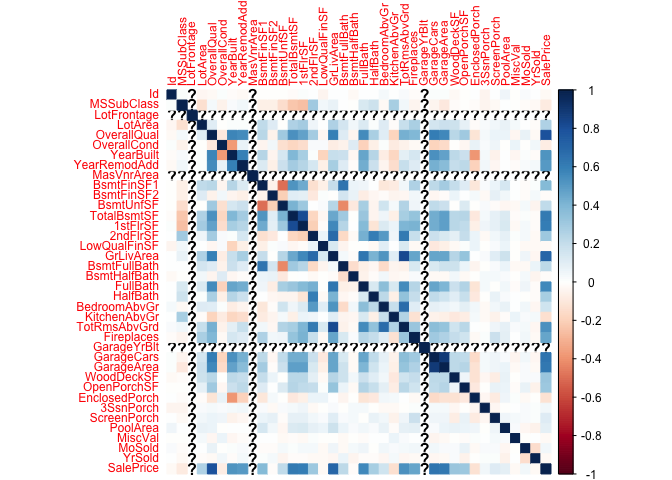

```r
corrplot(all_cors, method = "color", tl.cex = 0.75/par("cex"), cl.cex = 0.75/par("cex"))
```

```r
knitr::kable(sort(corr.test(all_cors, adjust = "none", alpha = 0.05)$p[38,]))
```

|  | x |
| --- | --- |
| SalePrice | 0.0000000 |
| OverallQual | 0.0000000 |
| GarageCars | 0.0000000 |
| GarageArea | 0.0000000 |
| GrLivArea | 0.0000000 |
| TotalBsmtSF | 0.0000000 |
| FullBath | 0.0000000 |
| YearBuilt | 0.0000000 |
| 1stFlrSF | 0.0000000 |
| YearRemodAdd | 0.0000000 |
| Fireplaces | 0.0000002 |
| TotRmsAbvGrd | 0.0000233 |
| OpenPorchSF | 0.0001013 |
| WoodDeckSF | 0.0002588 |
| BsmtFinSF1 | 0.0016888 |
| EnclosedPorch | 0.0049073 |
| OverallCond | 0.0059842 |
| BsmtUnfSF | 0.0097089 |
| LotArea | 0.0133459 |
| HalfBath | 0.0164044 |
| KitchenAbvGr | 0.0390804 |
| 2ndFlrSF | 0.0811710 |
| BsmtFullBath | 0.0935167 |
| MSSubClass | 0.1075909 |
| MiscVal | 0.1430074 |
| LowQualFinSF | 0.1623961 |
| BsmtHalfBath | 0.1891799 |
| BedroomAbvGr | 0.2165278 |
| YrSold | 0.2342366 |
| BsmtFinSF2 | 0.2501903 |
| Id | 0.2916207 |
| PoolArea | 0.7314335 |
| ScreenPorch | 0.7744910 |
| 3SsnPorch | 0.8583943 |
| MoSold | 0.9444445 |

```r
knitr::kable(sort(abs(all_cors['SalePrice',]), decreasing = TRUE)[2:11])
```

|  | x |
| --- | --- |
| OverallQual | 0.7909816 |
| GrLivArea | 0.7086245 |
| GarageCars | 0.6404092 |
| GarageArea | 0.6234314 |
| TotalBsmtSF | 0.6135806 |
| 1stFlrSF | 0.6058522 |
| FullBath | 0.5606638 |
| TotRmsAbvGrd | 0.5337232 |
| YearBuilt | 0.5228973 |
| YearRemodAdd | 0.5071010 |

۲. در یک تصویر نمودار پراکنش دو به دو ده متغیر بدست آمده به همراه قیمت را رسم نمایید و هم خطی بودن متغیرها را بررسی کنید

با توجه به نمودار، خطی بودن متغیرها به این صورت مشخص می شود که در صورتی که خط سبز رگرسیون و خط قرمز که رفتار متغیر را نشان می دهد، بر روی هم افتاده باشند، متغیر خطی بوده است.

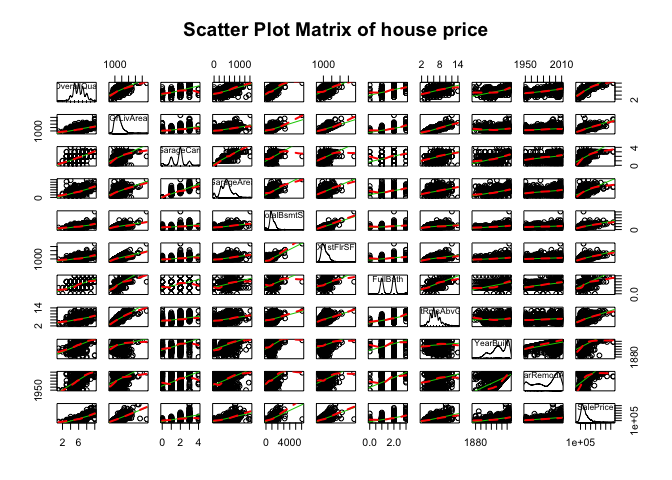

```r
library(car)

tops <- house_numeric %>% select(OverallQual,GrLivArea,GarageCars,GarageArea,TotalBsmtSF
                                ,`1stFlrSF`,FullBath,TotRmsAbvGrd,YearBuilt,YearRemodAdd
                                ,SalePrice)

scatterplotMatrix(tops, spread=FALSE, smoother.args=list(lty=2),
                  main="Scatter Plot Matrix of house price")
```

۳. یک مدل خطی بر اساس ده متغیر برای پیش بینی قیمت برازش دهید. و سپس خلاصه نتایج مدل را به دست آورید.

```r
reg_model = lm(SalePrice~., data = tops)

summary(reg_model)
```

```
Call:
lm(formula = SalePrice ~ ., data = tops)

Residuals:
    Min      1Q  Median      3Q     Max
-489958  -19316   -1948   16020  290558

Coefficients:
               Estimate Std. Error t value Pr(>|t|)
(Intercept)  -1.186e+06  1.291e+05  -9.187  < 2e-16 ***
OverallQual   1.960e+04  1.190e+03  16.472  < 2e-16 ***
GrLivArea     5.130e+01  4.233e+00  12.119  < 2e-16 ***
GarageCars    1.042e+04  3.044e+03   3.422 0.000639 ***
GarageArea    1.495e+01  1.031e+01   1.450 0.147384
TotalBsmtSF   1.986e+01  4.295e+00   4.625 4.09e-06 ***
`1stFlrSF`    1.417e+01  4.930e+00   2.875 0.004097 **
FullBath     -6.791e+03  2.682e+03  -2.532 0.011457 *
TotRmsAbvGrd  3.310e+01  1.119e+03   0.030 0.976404
YearBuilt     2.682e+02  5.035e+01   5.328 1.15e-07 ***
YearRemodAdd  2.965e+02  6.363e+01   4.659 3.47e-06 ***
---
Signif. codes:  0 '***' 0.001 '**' 0.01 '*' 0.05 '.' 0.1 ' ' 1

Residual standard error: 37920 on 1449 degrees of freedom
Multiple R-squared:  0.7737,    Adjusted R-squared:  0.7721
F-statistic: 495.4 on 10 and 1449 DF,  p-value: < 2.2e-16
```

۴. نمودار قیمت واقعی و قیمت پیش بینی را رسم نمایید و خوب بودن مدل را ارزیابی کنید.

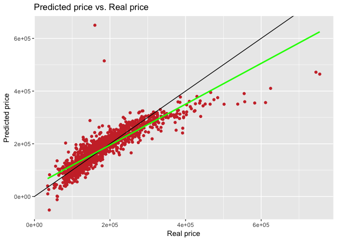

```r
predicted_price = predict(reg_model)

ggplot(house_numeric, aes(x=house_numeric$SalePrice, y=predicted_price)) + geom_point(colour = "brown3") +
  geom_abline(slope = 1) +
  geom_smooth(method="lm", se=FALSE, colour = "green") +
  xlab("Real price") +
  ylab("Predicted price") +
  ggtitle("Predicted price vs. Real price")
```

همانطور که مشاهده می کنیم، نمودار ما با نمودار y = x تفاوت نسبتا زیادی دارد، در نتیجه مدل خوبی نداریم. البته این انتظار منطقی است، زیرا همانطور که در سوال قبل در خلاصه ی مدل مشاهده کردیم، متغیرهای بدون تاثیر نیز در مدل ما وجود داشته است.(همچون تعداد اتاق ها و اندازه ی گاراژ)

۵. مقدار R-squared مدل را به دست آورید. آیا بر اساس این کمیت مدل به خوبی به داده ها برازش داده شده است؟ کمیت F-statistic را در خلاصه مدل تفسیر نمایید.

```r
summary(reg_model)$r.squared
```

```
[1] 0.7736928
```

مقدار R-squared برابر با ۷۷ درصد است، که در واقع نشان می دهد مدل ما ۷۷ درصد داده های حول میانگین را درست پیشبینی کرده است. در نتیجه ما دارای مدل خیلی خوبی نیستیم.

```r
summary(reg_model)$fstatistic
```

```
    value     numdf     dendf
 495.3802   10.0000 1449.0000
```

کمیت F-statistic نشان می دهد که چقد مدل ما با متغیرهایی که دارد، نسبت به مدلی که پیش بینی کننده ندارد (Precept Only) بهتر عمل می کند و در واقع متغیرهای استفاده برای پیشبینی چقدر تاثیرگذار هستند. در این تست فرض صفر یکسان بودن رفتار این دو مدل است. اما همانطور که می بینیم، مقدار F-statistic ۴۹۵ با درجه آزادی ۱۴۴۹ و ۱۰ دارای P-value بسیار کمی است، در نتیجه متغیرهای ما در بهبود مدل تاثیر داشته اند و مدل ما از مدل بدون پیشبینی کننده بهتر عمل می کند.

۶. بر اساس p-value سطح معناداری ضرایب تصمیم بگیرید که چه متغیرهایی در مدل سازی استفاده شود. بر اساس متغیرهای جدید دوباره مدل سازی کنید و نتایج رو گزارش دهید.

```r
summary(reg_model)
```

```
Call:
lm(formula = SalePrice ~ ., data = tops)

Residuals:
    Min      1Q  Median      3Q     Max
-489958  -19316   -1948   16020  290558

Coefficients:
               Estimate Std. Error t value Pr(>|t|)
(Intercept)  -1.186e+06  1.291e+05  -9.187  < 2e-16 ***
OverallQual   1.960e+04  1.190e+03  16.472  < 2e-16 ***
GrLivArea     5.130e+01  4.233e+00  12.119  < 2e-16 ***
GarageCars    1.042e+04  3.044e+03   3.422 0.000639 ***
GarageArea    1.495e+01  1.031e+01   1.450 0.147384
TotalBsmtSF   1.986e+01  4.295e+00   4.625 4.09e-06 ***
`1stFlrSF`    1.417e+01  4.930e+00   2.875 0.004097 **
FullBath     -6.791e+03  2.682e+03  -2.532 0.011457 *
TotRmsAbvGrd  3.310e+01  1.119e+03   0.030 0.976404
YearBuilt     2.682e+02  5.035e+01   5.328 1.15e-07 ***
YearRemodAdd  2.965e+02  6.363e+01   4.659 3.47e-06 ***
---
Signif. codes:  0 '***' 0.001 '**' 0.01 '*' 0.05 '.' 0.1 ' ' 1

Residual standard error: 37920 on 1449 degrees of freedom
Multiple R-squared:  0.7737,    Adjusted R-squared:  0.7721
F-statistic: 495.4 on 10 and 1449 DF,  p-value: < 2.2e-16
```

با توجه به نتایج و از آنجایی که خطای ما ۰.۰۵ است، دو متغیر GarageArea و TotRmsAbvGrd را که احتمالی بیشتر از دقت مورد ما دارند را حذف می کنیم. سپس مدل را دوباره ساخته و نمودار آن را می کشیم.

```r
# 0.05 error
new_tops <- tops %>% select(-TotRmsAbvGrd, -GarageArea)

new_reg_model = lm(SalePrice~., data = new_tops)

summary(new_reg_model)
```

```
Call:
lm(formula = SalePrice ~ ., data = new_tops)

Residuals:
    Min      1Q  Median      3Q     Max
-482525  -19191   -1801   16208  289639

Coefficients:
               Estimate Std. Error t value Pr(>|t|)
(Intercept)  -1.188e+06  1.284e+05  -9.255  < 2e-16 ***
OverallQual   1.959e+04  1.188e+03  16.486  < 2e-16 ***
GrLivArea     5.177e+01  3.097e+00  16.714  < 2e-16 ***
GarageCars    1.395e+04  1.817e+03   7.680 2.92e-14 ***
TotalBsmtSF   2.039e+01  4.269e+00   4.775 1.98e-06 ***
`1stFlrSF`    1.465e+01  4.919e+00   2.979  0.00294 **
FullBath     -7.184e+03  2.644e+03  -2.717  0.00666 **
YearBuilt     2.699e+02  5.017e+01   5.380 8.69e-08 ***
YearRemodAdd  2.957e+02  6.362e+01   4.649 3.64e-06 ***
---
Signif. codes:  0 '***' 0.001 '**' 0.01 '*' 0.05 '.' 0.1 ' ' 1

Residual standard error: 37920 on 1451 degrees of freedom
Multiple R-squared:  0.7734,    Adjusted R-squared:  0.7721
F-statistic: 618.9 on 8 and 1451 DF,  p-value: < 2.2e-16
```

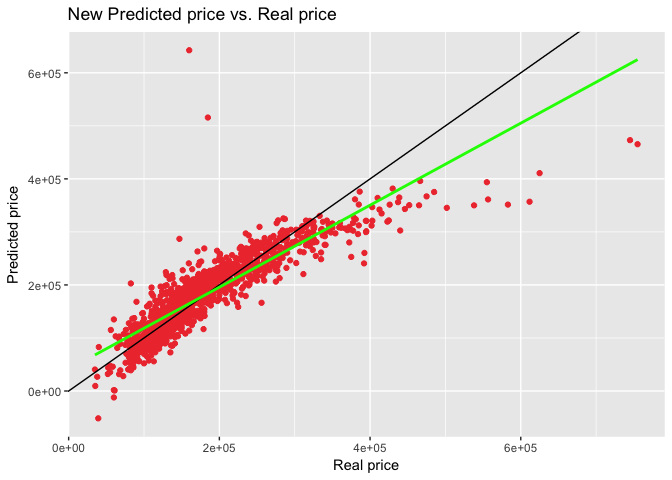

```r
new_predicted_price = predict(new_reg_model)

ggplot(house_numeric, aes(x=house_numeric$SalePrice, y=new_predicted_price)) + geom_point(colour = "brown2") +
  geom_abline(slope = 1) +
  geom_smooth(method="lm", se=FALSE, colour = "green") +
  xlab("Real price") +
  ylab("Predicted price") +
  ggtitle("New Predicted price vs. Real price")
```

۷. مدل خود را بر اساس باقی مانده نقص یابی کنید. سه محک normality, independance, Constant Variance را در نقص یابی خود در نظر بگیرید.

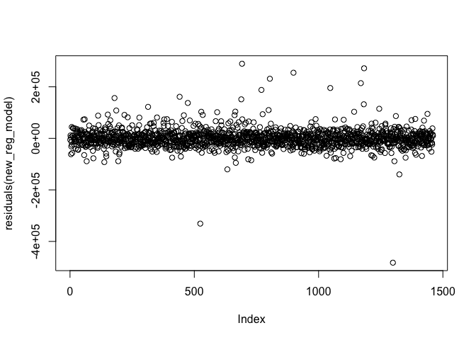

```r
plot(residuals(new_reg_model))
```

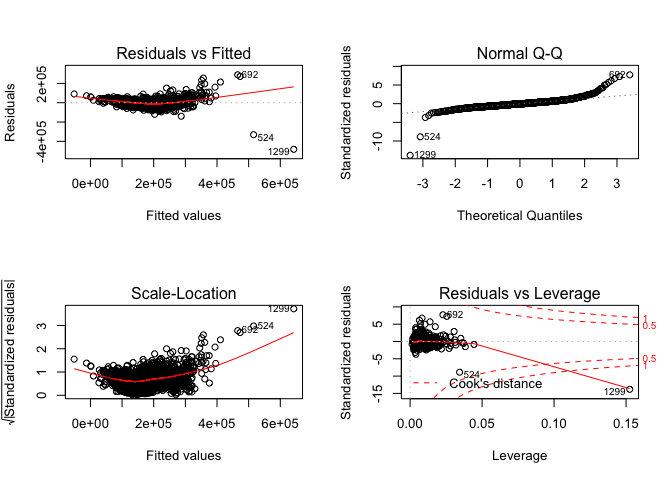

```r
par(mfrow=c(2,2))

plot(new_reg_model)
```

```r
par(mfrow=c(1,1))

cor.test(house_numeric$SalePrice, residuals(new_reg_model))
```

```
    Pearson's product-moment correlation

data:  house_numeric$SalePrice and residuals(new_reg_model)
t = 20.671, df = 1458, p-value < 2.2e-16
alternative hypothesis: true correlation is not equal to 0
95 percent confidence interval:
 0.4353946 0.5147926
sample estimates:
      cor
0.4760632
```

```r
data = data.frame(house_numeric$SalePrice, abs(residuals(new_reg_model)))
data_matrix <- data %>% .[,-1] %>% as.matrix()

chisq.test(data_matrix)
```

```
    Chi-squared test for given probabilities

data:  data_matrix
X-squared = 51945000, df = 1459, p-value < 2.2e-16
```

۸. داده ها را به پنج قسمت تقسیم کنید. بر اساس چهار قسمت مدل خطی را بسازید و صحت مدل را برای یک قسمت باقی مانده را تست کنید. خطای پیش بینی شما چقدر است؟

```r
sample = sample(1:length(new_tops$SalePrice), size = length(new_tops$SalePrice)*0.8)

train_set = new_tops[sample,]
test_set = new_tops[-sample,]

train_reg_model = lm(SalePrice~., data = train_set)
summary(train_reg_model)
```

```
Call:
lm(formula = SalePrice ~ ., data = train_set)

Residuals:
    Min      1Q  Median      3Q     Max
-377207  -18869   -1612   16442  255670

Coefficients:
               Estimate Std. Error t value Pr(>|t|)
(Intercept)  -1.258e+06  1.381e+05  -9.109  < 2e-16 ***
OverallQual   1.772e+04  1.286e+03  13.777  < 2e-16 ***
GrLivArea     6.388e+01  3.377e+00  18.916  < 2e-16 ***
GarageCars    1.050e+04  1.924e+03   5.455 5.97e-08 ***
TotalBsmtSF   3.559e+01  4.932e+00   7.215 9.75e-13 ***
`1stFlrSF`    1.030e+01  5.492e+00   1.875 0.061009 .
FullBath     -1.110e+04  2.868e+03  -3.872 0.000114 ***
YearBuilt     2.835e+02  5.386e+01   5.264 1.68e-07 ***
YearRemodAdd  3.153e+02  6.810e+01   4.630 4.06e-06 ***
---
Signif. codes:  0 '***' 0.001 '**' 0.01 '*' 0.05 '.' 0.1 ' ' 1

Residual standard error: 36430 on 1159 degrees of freedom
Multiple R-squared:  0.8025,    Adjusted R-squared:  0.8012
F-statistic: 588.8 on 8 and 1159 DF,  p-value: < 2.2e-16
```

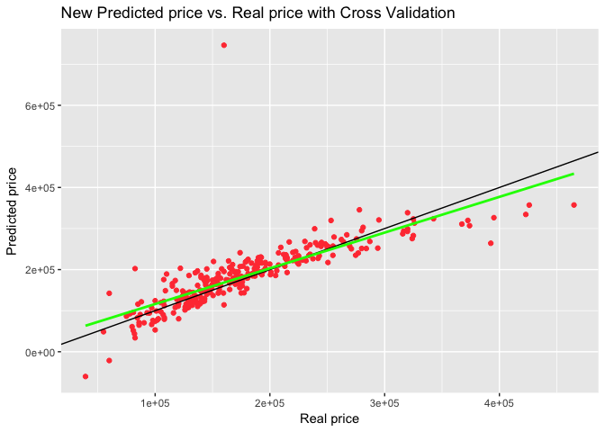

```r
predicted = predict(train_reg_model , test_set)

ggplot(test_set, aes(x=test_set$SalePrice, y=predicted)) + geom_point(colour = "brown1") +
  geom_abline(slope = 1) +
  geom_smooth(method="lm", se=FALSE, colour = "green") +
  xlab("Real price") +
  ylab("Predicted price") +
  ggtitle("New Predicted price vs. Real price with Cross Validation")
```

۹. آیا قیمت ربط غیر خطی با یکی از ده متغیر استفاده شده دارد؟ بر اساس دستاوردهای خود مدل را بهتر نمایید.

```r
library(gam)
second = tops$OverallQual^2

cor.test(tops$SalePrice, second)
```

```
    Pearson's product-moment correlation

data:  tops$SalePrice and second
t = 54.134, df = 1458, p-value < 2.2e-16
alternative hypothesis: true correlation is not equal to 0
95 percent confidence interval:
 0.7993782 0.8335271
sample estimates:
      cor
0.8171684
```

```r
edit_reg_model = lm(SalePrice~ I(OverallQual^2) + GrLivArea + GarageCars + TotalBsmtSF + I(1.1^`1stFlrSF`)
                    + FullBath + YearBuilt + YearRemodAdd + GarageArea, data = tops)
summary(edit_reg_model)
```

```
Call:
lm(formula = SalePrice ~ I(OverallQual^2) + GrLivArea + GarageCars +
    TotalBsmtSF + I(1.1^`1stFlrSF`) + FullBath + YearBuilt +
    YearRemodAdd + GarageArea, data = tops)

Residuals:
    Min      1Q  Median      3Q     Max
-376838  -18447   -1203   15285  248610

Coefficients:
                     Estimate  Std. Error t value Pr(>|t|)
(Intercept)        -1.101e+06   1.148e+05  -9.592  < 2e-16 ***
I(OverallQual^2)    1.670e+03   8.398e+01  19.883  < 2e-16 ***
GrLivArea           5.852e+01   2.724e+00  21.487  < 2e-16 ***
GarageCars          1.935e+03   2.752e+03   0.703 0.482062
TotalBsmtSF         3.631e+01   2.667e+00  13.615  < 2e-16 ***
I(1.1^`1stFlrSF`) -3.618e-189   0.000e+00    -Inf  < 2e-16 ***
FullBath           -1.016e+04   2.382e+03  -4.267 2.11e-05 ***
YearBuilt           2.723e+02   4.455e+01   6.111 1.27e-09 ***
YearRemodAdd        2.770e+02   5.665e+01   4.890 1.12e-06 ***
GarageArea          3.442e+01   9.255e+00   3.719 0.000208 ***
---
Signif. codes:  0 '***' 0.001 '**' 0.01 '*' 0.05 '.' 0.1 ' ' 1

Residual standard error: 33830 on 1450 degrees of freedom
Multiple R-squared:  0.8198,    Adjusted R-squared:  0.8187
F-statistic: 732.9 on 9 and 1450 DF,  p-value: < 2.2e-16
```

ابتدا سعی می کنیم، از میان داده ها، داده ای که مربع آن بیشترین کوریلیشن را با قیمت دارد یافته و در مدل منظور کنیم. از طرفی بر اساس نمودار پراکنش متوجه می شویم که داده ی 1stFlrSF نیز نموداری شبیه نمایی با قیمت دارد، به همین علت آن را نیز به فرم نمایی در می آوریم. سپس مدل را ساخته و می بینیم که میزان خطای مدل کمتر شده و مدل بهبود یافته است.

```r
gam_model = gam(SalePrice~ s(OverallQual) + s(GrLivArea) + s(GarageCars) + s(GarageArea) + s(TotalBsmtSF) +
                  + s(`1stFlrSF`) + (FullBath) + s(TotRmsAbvGrd) + s(YearBuilt) + s(YearRemodAdd), data=tops)
summary(gam_model)
```

```
Call: gam(formula = SalePrice ~ s(OverallQual) + s(GrLivArea) + s(GarageCars) +
    s(GarageArea) + s(TotalBsmtSF) + +s(`1stFlrSF`) + (FullBath) +
    s(TotRmsAbvGrd) + s(YearBuilt) + s(YearRemodAdd), data = tops)
Deviance Residuals:
      Min        1Q    Median        3Q       Max
-341835.9  -14002.3    -258.5   12801.2  210703.8

(Dispersion Parameter for gaussian family taken to be 909274498)

    Null Deviance: 9.207911e+12 on 1459 degrees of freedom
Residual Deviance: 1.292988e+12 on 1422 degrees of freedom
AIC: 34299.91

Number of Local Scoring Iterations: 4

Anova for Parametric Effects
                  Df     Sum Sq    Mean Sq   F value    Pr(>F)
s(OverallQual)     1 5.8964e+12 5.8964e+12 6484.7609 < 2.2e-16 ***
s(GrLivArea)       1 8.4801e+11 8.4801e+11  932.6232 < 2.2e-16 ***
s(GarageCars)      1 1.8316e+11 1.8316e+11  201.4336 < 2.2e-16 ***
s(GarageArea)      1 1.4715e+10 1.4715e+10   16.1834 6.052e-05 ***
s(TotalBsmtSF)     1 1.5235e+11 1.5235e+11  167.5473 < 2.2e-16 ***
s(`1stFlrSF`)      1 7.6411e+09 7.6411e+09    8.4035 0.0038025 **
FullBath           1 7.5722e+09 7.5722e+09    8.3278 0.0039633 **
s(TotRmsAbvGrd)    1 1.1320e+10 1.1320e+10   12.4494 0.0004314 ***
s(YearBuilt)       1 1.0133e+11 1.0133e+11  111.4439 < 2.2e-16 ***
s(YearRemodAdd)    1 6.2837e+10 6.2837e+10   69.1071 < 2.2e-16 ***
Residuals       1422 1.2930e+12 9.0927e+08
---
Signif. codes:  0 '***' 0.001 '**' 0.01 '*' 0.05 '.' 0.1 ' ' 1

Anova for Nonparametric Effects
                Npar Df Npar F     Pr(F)
(Intercept)
s(OverallQual)        3 70.410 < 2.2e-16 ***
s(GrLivArea)          3 24.780 1.332e-15 ***
s(GarageCars)         3  3.317  0.019265 *
s(GarageArea)         3  2.370  0.068946 .
s(TotalBsmtSF)        3 25.744 3.331e-16 ***
s(`1stFlrSF`)         3 50.290 < 2.2e-16 ***
FullBath
s(TotRmsAbvGrd)       3  1.391  0.243814
s(YearBuilt)          3  8.852 8.168e-06 ***
s(YearRemodAdd)       3  5.410  0.001059 **
---
Signif. codes:  0 '***' 0.001 '**' 0.01 '*' 0.05 '.' 0.1 ' ' 1
```

```r
gam_model = gam(SalePrice~ s(OverallQual) + s(GrLivArea) + s(TotalBsmtSF) +
                  + s(`1stFlrSF`) + (FullBath) + s(YearBuilt) + s(YearRemodAdd), data=tops)
summary(gam_model)
```

```
Call: gam(formula = SalePrice ~ s(OverallQual) + s(GrLivArea) + s(TotalBsmtSF) +
    +s(`1stFlrSF`) + (FullBath) + s(YearBuilt) + s(YearRemodAdd),
    data = tops)
Deviance Residuals:
      Min        1Q    Median        3Q       Max
-338752.1  -14315.0    -136.6   13639.5  207358.5

(Dispersion Parameter for gaussian family taken to be 950041051)

    Null Deviance: 9.207911e+12 on 1459 degrees of freedom
Residual Deviance: 1.362359e+12 on 1434 degrees of freedom
AIC: 34352.21

Number of Local Scoring Iterations: 4

Anova for Parametric Effects
                  Df     Sum Sq    Mean Sq   F value    Pr(>F)
s(OverallQual)     1 5.9296e+12 5.9296e+12 6241.4529 < 2.2e-16 ***
s(GrLivArea)       1 8.5022e+11 8.5022e+11  894.9335 < 2.2e-16 ***
s(TotalBsmtSF)     1 2.2096e+11 2.2096e+11  232.5839 < 2.2e-16 ***
s(`1stFlrSF`)      1 5.0099e+09 5.0099e+09    5.2734  0.021798 *
FullBath           1 1.2865e+10 1.2865e+10   13.5415  0.000242 ***
s(YearBuilt)       1 1.6765e+11 1.6765e+11  176.4613 < 2.2e-16 ***
s(YearRemodAdd)    1 6.0247e+10 6.0247e+10   63.4151  3.38e-15 ***
Residuals       1434 1.3624e+12 9.5004e+08
---
Signif. codes:  0 '***' 0.001 '**' 0.01 '*' 0.05 '.' 0.1 ' ' 1

Anova for Nonparametric Effects
                Npar Df Npar F     Pr(F)
(Intercept)
s(OverallQual)        3 81.921 < 2.2e-16 ***
s(GrLivArea)          3 25.368 5.551e-16 ***
s(TotalBsmtSF)        3 29.225 < 2.2e-16 ***
s(`1stFlrSF`)         3 60.231 < 2.2e-16 ***
FullBath
s(YearBuilt)          3  7.058 0.0001040 ***
s(YearRemodAdd)       3  6.554 0.0002118 ***
---
Signif. codes:  0 '***' 0.001 '**' 0.01 '*' 0.05 '.' 0.1 ' ' 1
```

۱۰. بر اساس مدل نهایی به دست آمده نتایج پیش بینی خود را بر روی test.csv به دست آورید و در سایت kaggle در مسابقه House Prices: Advanced Regression Techniques بارگذاری نمایید. سپس لینک رتبه و عدد آن را ضمیمه تمرین کنید.

```r
final_predict = predict(edit_reg_model, house_test)
house_test$SalePrice = final_predict

res <- house_test %>% select(Id, SalePrice) %>%
  mutate(SalePrice = ifelse(!is.na(SalePrice),SalePrice,mean(SalePrice, na.rm = TRUE)))

write.csv(res, file = "kaggle/ans.csv",row.names=FALSE)

final_predict = predict(gam_model, house_test)
house_test$SalePrice = final_predict

res <- house_test %>% select(Id, SalePrice) %>%
  mutate(SalePrice = ifelse(!is.na(SalePrice),SalePrice,mean(SalePrice, na.rm = TRUE)))

write.csv(res, file = "kaggle/gam_ans.csv",row.names=FALSE)
```

برای این سوال، ابتدا نتایج مدل خطی بهبود داده شده در سوال ۹ را آپلود می کنیم، که مشاهده می کنیم، دارای ۰.۴۹ خطا بوده و رتبه ی ۴۶۰۶ را کسب کرد. سپس از مدل خطی بدون بهبود استفاده می کنیم که خطای آن بیشتر بوده و دارای ۰.۷۲ خطا است. در نهایت از مدل gam استفاده می کنیم که اختلاف فاحشی با مدل های خطی دارد و تنها ۰.۱۶ خطا دارد و رتبه ی ۲۸۷۴ را کسب کرد.  
لینک: https://www.kaggle.com/minam75